# Summer_2

Joey Lin

2026-07-19

# Goals:

1. Elevation vs Oxygen level by species with sample size of at least 3 per species (follow up from summer 1 plot with n>=5)
2. Boxplot of oxygen level vs species/subgenus (include all points in box) using smplot
3. Explore if pham ratios are consistent across species
4. Boxplot of queens vs workers/caste (male/female) *intraspecies (facet by species)*

Load the data

```r
library(tidyverse)
library(here)
metadata <- read_csv("../Data/merged_oxymetag.csv")
```

## 1. Elevation vs Oxygen level by species (n>=3)

*assign color palette for species*

```r
species_palette <- c(
  "rubicundus"            = "#AD2632",
  "funebris"              = "#D36800",
  "hortulanus"            = "#BC8700",
  "robustus"              = "#DEBA00",
  "rufocinctus"           = "#E6625F",
  "morrisoni"             = "#FF855D",
  "griseocollis"          = "#FEA124",
  "vandykei"              = "#5951BE",
  "flavifrons_dimidiatus"  = "#6D37A0",
  "flavifrons_flavifrons"  = "#4D218C",
  "bifarius"              = "#B54C9B",
  "bifarius_nearcticus"   = "#DA65AA",
  "sylvicola"             = "#9A54BA",
  "huntii"                = "#862A85",
  "mixtus"                = "#CD4E77",
  "vosnesenskii"          = "#7C64D4",
  "fervidus"              = "#6E9887",
  "pensylvanicus"         = "#00A59E",
  "sonorus"               = "#006674",
  "atratus"               = "#007FB1",
  "insularis"             = "#67C864",
  "nevadensis"            = "#A4A4A4"
)
```

*generate the graph*

[figure not shown]

```r
metadata %>%
  # Remove rows missing elevation or oxygen measurements
  filter(!is.na(elev_masl), !is.na(Oxygen_level)) %>%

  # Temporarily group by species to count them
  group_by(species_id) %>%

  # EXCLUDE species from the graph if they have fewer than 10 samples
  filter(n() >= 3) %>%

  # Ungroup so ggplot handles the data properly
  ungroup() %>%

  # Send this filtered subset straight to the graph
  ggplot(aes(x = elev_masl, y = Oxygen_level, color = species_id)) +
  geom_point(size = 3, alpha = 0.8) +
  scale_color_manual(values = species_palette) +
  labs(
    title = "Elevation vs. Oxygen Level by Bumblebee Species",
    subtitle = "Excluding species with a sample size of less than 5",
    x = "Elevation (meters above sea level)",
    y = "Oxygen Level (%)",
    color = "Species ID"
  ) +
  theme_minimal(base_size = 13) +
  theme(
    plot.title = element_text(face = "bold", hjust = 0.5),
    plot.subtitle = element_text(size = 10, color = "gray40", hjust = 0.5, margin = margin(b = 15)),
    axis.title.x = element_text(margin = margin(t = 10)),
    axis.title.y = element_text(margin = margin(r = 10)),
    legend.title = element_text(face = "bold"),
    panel.grid.minor = element_blank()
  ) +
  geom_smooth(method = "lm", se = FALSE, color = "black", linetype = "dashed")
```

*Check if the slope is significantly negative*

```r
model_elev <- lm(Oxygen_level ~ elev_masl, data = metadata %>%
  filter(!is.na(elev_masl), !is.na(Oxygen_level)) %>%
  group_by(species_id) %>%
  filter(n() >= 3) %>%
  ungroup())

summary(model_elev)
```

```
##
## Call:
## lm(formula = Oxygen_level ~ elev_masl, data = metadata %>% filter(!is.na(elev_masl),
##     !is.na(Oxygen_level)) %>% group_by(species_id) %>% filter(n() >=
##     3) %>% ungroup())
##
## Residuals:
##      Min       1Q   Median       3Q      Max
## -29.3674  -6.9197   0.4247   4.5802  27.6601
##
## Coefficients:
##              Estimate Std. Error t value Pr(>|t|)
## (Intercept) 86.349098   4.406303  19.597   <2e-16 ***
## elev_masl   -0.004112   0.001899  -2.165    0.034 *
## ---
## Signif. codes:  0 '***' 0.001 '**' 0.01 '*' 0.05 '.' 0.1 ' ' 1
##
## Residual standard error: 12.74 on 66 degrees of freedom
## Multiple R-squared:  0.06633,    Adjusted R-squared:  0.05218
## F-statistic: 4.689 on 1 and 66 DF,  p-value: 0.03398
```

The slope is statistically significantly negative at (alpha=0.05). The R^2 is small. Lets try to add speices as a control variable in the regression:

```r
model_species <- lm(Oxygen_level ~ elev_masl + species_id, data = metadata %>%
  filter(!is.na(elev_masl), !is.na(Oxygen_level)) %>%
  group_by(species_id) %>%
  filter(n() >= 3) %>%
  ungroup())

summary(model_species)
```

```
##
## Call:
## lm(formula = Oxygen_level ~ elev_masl + species_id, data = metadata %>%
##     filter(!is.na(elev_masl), !is.na(Oxygen_level)) %>% group_by(species_id) %>%
##     filter(n() >= 3) %>% ungroup())
##
## Residuals:
##     Min      1Q  Median      3Q     Max
## -21.225  -4.894  -1.073   4.827  18.569
##
## Coefficients:
##                           Estimate Std. Error t value Pr(>|t|)
## (Intercept)              5.464e+01  8.302e+00   6.582 1.58e-08 ***
## elev_masl               -5.553e-06  2.718e-03  -0.002 0.998377
## species_idfervidus       3.019e+01  5.912e+00   5.106 3.95e-06 ***
## species_idfunebris       1.927e+01  7.346e+00   2.624 0.011147 *
## species_idhortulanus     2.606e+01  6.919e+00   3.766 0.000395 ***
## species_idhuntii         3.089e+01  6.157e+00   5.018 5.44e-06 ***
## species_idmorrisoni      2.830e+01  5.765e+00   4.909 8.03e-06 ***
## species_idpensylvanicus  2.652e+01  7.826e+00   3.389 0.001280 **
## species_idrobustus       3.976e+00  6.529e+00   0.609 0.544928
## species_idrubicundus     2.675e+01  7.126e+00   3.755 0.000410 ***
## species_idsonorus        1.817e+01  6.126e+00   2.966 0.004398 **
## ---
## Signif. codes:  0 '***' 0.001 '**' 0.01 '*' 0.05 '.' 0.1 ' ' 1
##
## Residual standard error: 9.733 on 57 degrees of freedom
## Multiple R-squared:  0.529,  Adjusted R-squared:  0.4464
## F-statistic: 6.403 on 10 and 57 DF,  p-value: 1.629e-06
```

### Conclusion: Elevation is no longer significant after controlling for species. However, speices is highly significanty and accounts for way higher variation (R^2 = 0.529). One concern is that species can be highly correlated with elevation, causing my multiple regression test to be unrelaible (multicollinearity).

### Concern: Maybe month can come into play here. Lets check:

```r
metadata <- metadata %>%
  mutate(month = as.integer(substr(date, 1, 2)))
model_month_species <- lm(Oxygen_level ~ month + species_id, data = metadata %>%
  filter(!is.na(Oxygen_level), !is.na(month), !is.na(species_id)))

summary(model_month_species)
```

```
##
## Call:
## lm(formula = Oxygen_level ~ month + species_id, data = metadata %>%
##     filter(!is.na(Oxygen_level), !is.na(month), !is.na(species_id)))
##
## Residuals:
##     Min      1Q  Median      3Q     Max
## -43.206  -4.858  -0.201   6.788  26.666
##
## Coefficients:
##                                 Estimate Std. Error t value Pr(>|t|)
## (Intercept)                      53.4627     6.3818   8.377 2.28e-12 ***
## month                             0.5182     1.1930   0.434 0.665234
## species_idfervidus               27.9375     8.5943   3.251 0.001725 **
## species_idflavifrons_dimidiatus  42.9097    14.1324   3.036 0.003293 **
## species_idflavifrons_flavifrons  15.7251    12.1500   1.294 0.199552
## species_idfunebris               19.5264     8.2099   2.378 0.019935 *
## species_idgriseocollis           43.4279    13.6978   3.170 0.002205 **
## species_idhortulanus             26.5755     8.2746   3.212 0.001945 **
## species_idhuntii                 28.5065     9.1042   3.131 0.002482 **
## species_idinsularis              43.4279    13.6978   3.170 0.002205 **
## species_idmorrisoni              25.9175     8.5621   3.027 0.003384 **
## species_idnevadensis             13.8940    10.9810   1.265 0.209689
## species_idpensylvanicus          23.8092     9.7518   2.442 0.016983 *
## species_idrobustus                4.1021     7.4807   0.548 0.585078
## species_idrubicundus             27.1381     8.2369   3.295 0.001506 **
## species_idrufocinctus            42.3914    14.6516   2.893 0.004988 **
## species_idsonorus                15.1955     9.7712   1.555 0.124122
## species_idvandykei               43.1688    11.2372   3.842 0.000254 ***
## species_idvosnesenskii           33.0792     8.2225   4.023 0.000136 ***
## ---
## Signif. codes:  0 '***' 0.001 '**' 0.01 '*' 0.05 '.' 0.1 ' ' 1
##
## Residual standard error: 11.58 on 75 degrees of freedom
## Multiple R-squared:  0.5163, Adjusted R-squared:  0.4003
## F-statistic: 4.448 on 18 and 75 DF,  p-value: 2.187e-06
```

Month is not associated with oxygen level after controlling for species.

## 2. Boxplot of Oxygen level vs species/subgenus (include all data points)

*install smplot2* install.packages(“smplot2”)

```r
library (smplot2)
```

```
## Updated tutorial for smplot2: smin95.github.io/dataviz/
```

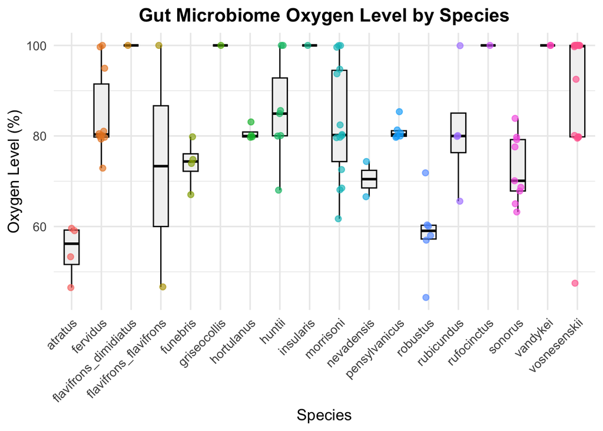

```r
metadata %>%
  filter(!is.na(Oxygen_level), !is.na(species_id)) %>%
  ggplot(aes(x = species_id, y = Oxygen_level, color = species_id)) +
  sm_boxplot() +
  labs(
    title = "Gut Microbiome Oxygen Level by Species",
    x = "Species",
    y = "Oxygen Level (%)"
  ) +
  theme_minimal(base_size = 13) +
  theme(
    axis.text.x = element_text(angle = 45, hjust = 1),
    legend.position = "none",
    plot.title = element_text(face = "bold", hjust = 0.5)
  )
```

*now do one with subgenus (color by country)*

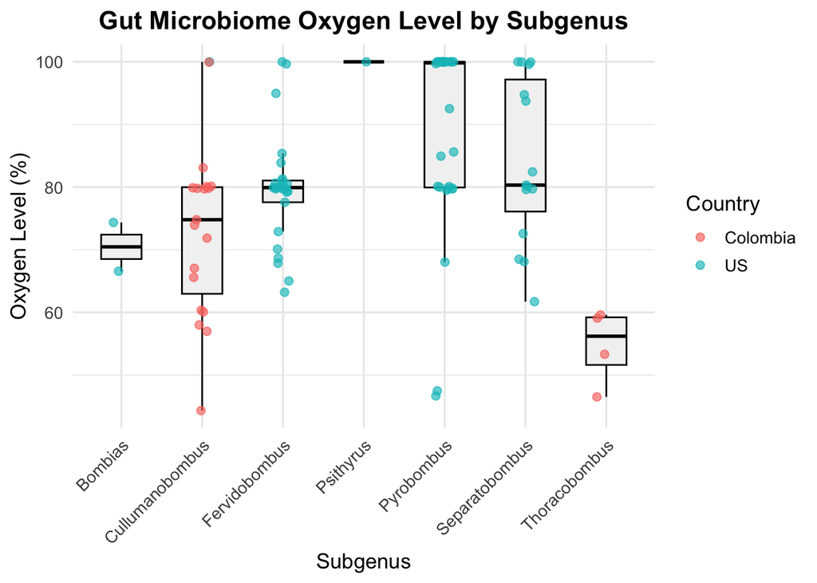

```r
metadata %>%
  filter(!is.na(Oxygen_level)) %>%
  ggplot(aes(x = subgenus, y = Oxygen_level, color = country)) +
  sm_boxplot() +
  labs(
    title = "Gut Microbiome Oxygen Level by Subgenus",
    x = "Subgenus",
    y = "Oxygen Level (%)",
    color = "Country"
  ) +
  theme_minimal(base_size = 13) +
  theme(
    axis.text.x = element_text(angle = 45, hjust = 1),
    plot.title = element_text(face = "bold", hjust = 0.5)
  )
```

Now, I will run a statistical test comparing subgenus

```r
model_subgenus <- aov(Oxygen_level ~ subgenus, data = metadata %>%
                        filter(!is.na(Oxygen_level), !is.na(subgenus)))
summary(model_subgenus)
```

```
##             Df Sum Sq Mean Sq F value   Pr(>F)
## subgenus     6   6297  1049.6   6.299 1.57e-05 ***
## Residuals   87  14496   166.6
## ---
## Signif. codes:  0 '***' 0.001 '**' 0.01 '*' 0.05 '.' 0.1 ' ' 1
```

```r
# Post-hoc test to see which subgenera differ
TukeyHSD(model_subgenus)
```

```
##   Tukey multiple comparisons of means
##     95% family-wise confidence level
##
## Fit: aov(formula = Oxygen_level ~ subgenus, data = metadata %>% filter(!is.na(Oxygen_level), !is.na(subgenus)))
##
## $subgenus
##                                      diff        lwr        upr     p adj
## Cullumanobombus-Bombias          2.978500 -25.985531  31.942531 0.9999236
## Fervidobombus-Bombias            9.149687 -19.481413  37.780787 0.9601906
## Psithyrus-Bombias               29.533891 -18.184608  77.252391 0.5066981
## Pyrobombus-Bombias              18.244409 -10.272849  46.761667 0.4657970
## Separatobombus-Bombias          13.605442 -15.724080  42.934964 0.8002974
## Thoracobombus-Bombias          -15.837412 -49.579486  17.904663 0.7913895
## Fervidobombus-Cullumanobombus    6.171187  -5.687065  18.029439 0.7010011
## Psithyrus-Cullumanobombus       26.555391 -13.418769  66.529551 0.4189708
## Pyrobombus-Cullumanobombus      15.265909   3.685223  26.846594 0.0026405
## Separatobombus-Cullumanobombus  10.626942  -2.830366  24.084249 0.2181142
## Thoracobombus-Cullumanobombus  -18.815912 -40.249667   2.617844 0.1240865
## Psithyrus-Fervidobombus         20.384204 -19.349387  60.117795 0.7148092
## Pyrobombus-Fervidobombus         9.094722  -1.626149  19.815592 0.1512655
## Separatobombus-Fervidobombus     4.455755  -8.269179  17.180688 0.9387252
## Thoracobombus-Fervidobombus    -24.987099 -45.968774  -4.005424 0.0093500
## Pyrobombus-Psithyrus           -11.289482 -50.941121  28.362156 0.9774960
## Separatobombus-Psithyrus       -15.928449 -56.168221  24.311323 0.8943216
## Thoracobombus-Psithyrus        -45.371303 -88.932134  -1.810472 0.0355844
## Separatobombus-Pyrobombus       -4.638967 -17.105645   7.827711 0.9192949
## Thoracobombus-Pyrobombus       -34.081820 -54.907881 -13.255760 0.0000751
## Thoracobombus-Separatobombus   -29.442854 -51.367991  -7.517716 0.0020427
```

```r
library(car)
vif(model_species)
```

```
##                GVIF Df GVIF^(1/(2*Df))
## elev_masl  3.505945  1        1.872417
## species_id 3.505945  9        1.072178
```

### Concern: I had a question about multicollinearity between species and elevation. Claude told me to run the Vif test. Conculsion: there is no pure mathematical collinearity problem. Maybe run PGLS just to make sure?

## 3. Pham ratio consistency

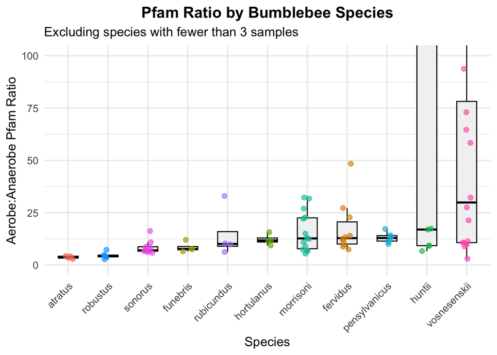

```r
metadata %>%
  filter(!is.na(ratio), !is.na(species_id)) %>%
  group_by(species_id) %>%
  filter(n() >= 3) %>%
  ungroup() %>%
  ggplot(aes(x = reorder(species_id, ratio, median, na.rm = TRUE),
             y = ratio, color = species_id)) +
  sm_boxplot(outlier.shape = NA) +
  coord_cartesian(ylim = c(0, 100)) +
  labs(
    title = "Pfam Ratio by Bumblebee Species",
    subtitle = "Excluding species with fewer than 3 samples",
    x = "Species",
    y = "Aerobe:Anaerobe Pfam Ratio"
  ) +
  theme_minimal(base_size = 13) +
  theme(
    axis.text.x = element_text(angle = 45, hjust = 1),
    legend.position = "none",
    plot.title = element_text(face = "bold", hjust = 0.5)
  )
```

### Observation: the plot is consistent with oxygen levels. Atratus and robustus have the lowest and consistent ratios. Huntii and vosnesenskii have the highest ratios and variability.

```r
model_ratio_species <- aov(ratio ~ species_id, data = metadata %>%
  filter(!is.na(ratio), !is.na(species_id)) %>%
  group_by(species_id) %>%
  filter(n() >= 3) %>%
  ungroup())

summary(model_ratio_species)
```

```
##             Df  Sum Sq Mean Sq F value Pr(>F)
## species_id  10  865864   86586   1.865 0.0642 .
## Residuals   73 3388808   46422
## ---
## Signif. codes:  0 '***' 0.001 '**' 0.01 '*' 0.05 '.' 0.1 ' ' 1
```

```r
TukeyHSD(model_ratio_species)
```

```
##   Tukey multiple comparisons of means
##     95% family-wise confidence level
##
## Fit: aov(formula = ratio ~ species_id, data = metadata %>% filter(!is.na(ratio), !is.na(species_id)) %>% group_by(species_id) %>% filter(n() >= 3) %>% ungroup())
##
## $species_id
##                                     diff         lwr        upr     p adj
## fervidus-atratus             13.81940226 -409.734980 437.373785 1.0000000
## funebris-atratus              4.78114967 -501.463166 511.025465 1.0000000
## hortulanus-atratus            8.45330243 -497.791013 514.697618 1.0000000
## huntii-atratus              371.91316047  -76.824464 820.650785 0.1972034
## morrisoni-atratus            12.18458157 -393.713872 418.083035 1.0000000
## pensylvanicus-atratus         9.37518756 -452.760531 471.510907 1.0000000
## robustus-atratus              0.83498691 -461.300732 462.970706 1.0000000
## rubicundus-atratus           11.15521038 -495.089105 517.399526 1.0000000
## sonorus-atratus               4.80783321 -425.417108 435.032774 1.0000000
## vosnesenskii-atratus         97.52153994 -302.699733 497.742813 0.9991607
## funebris-fervidus            -9.03825259 -432.592635 414.516130 1.0000000
## hortulanus-fervidus          -5.36609983 -428.920483 418.188283 1.0000000
## huntii-fervidus             358.09375821    5.275868 710.911648 0.0436572
## morrisoni-fervidus           -1.63482069 -298.061140 294.791498 1.0000000
## pensylvanicus-fervidus       -4.44421470 -374.152790 365.264360 1.0000000
## robustus-fervidus           -12.98441536 -382.692991 356.724160 1.0000000
## rubicundus-fervidus          -2.66419189 -426.218575 420.890191 1.0000000
## sonorus-fervidus             -9.01156905 -337.962185 319.939047 1.0000000
## vosnesenskii-fervidus        83.70213768 -204.901526 372.305802 0.9963902
## hortulanus-funebris           3.67215276 -502.572163 509.916469 1.0000000
## huntii-funebris             367.13201080  -81.605614 815.869635 0.2121840
## morrisoni-funebris            7.40343190 -398.495022 413.301886 1.0000000
## pensylvanicus-funebris        4.59403789 -457.541681 466.729757 1.0000000
## robustus-funebris            -3.94616276 -466.081882 458.189556 1.0000000
## rubicundus-funebris           6.37406070 -499.870255 512.618377 1.0000000
## sonorus-funebris              0.02668354 -430.198257 430.251624 1.0000000
## vosnesenskii-funebris        92.74039027 -307.480882 492.961663 0.9994577
## huntii-hortulanus           363.45985804  -85.277767 812.197483 0.2242195
## morrisoni-hortulanus          3.73127914 -402.167175 409.629733 1.0000000
## pensylvanicus-hortulanus      0.92188513 -461.213834 463.057604 1.0000000
## robustus-hortulanus          -7.61831553 -469.754034 454.517403 1.0000000
## rubicundus-hortulanus         2.70190794 -503.542408 508.946224 1.0000000
## sonorus-hortulanus           -3.64546922 -433.870410 426.579472 1.0000000
## vosnesenskii-hortulanus      89.06823751 -311.153035 489.289510 0.9996199
## morrisoni-huntii           -359.72857891 -691.143279 -28.313879 0.0223603
## pensylvanicus-huntii       -362.53797291 -760.848871  35.772925 0.1073079
## robustus-huntii            -371.07817357 -769.389071  27.232724 0.0901707
## rubicundus-huntii          -360.75795010 -809.495575  87.979674 0.2333696
## sonorus-huntii             -367.10532726 -727.903953  -6.306702 0.0426584
## vosnesenskii-huntii        -274.39162053 -598.828387  50.045146 0.1749662
## pensylvanicus-morrisoni      -2.80939401 -352.151161 346.532373 1.0000000
## robustus-morrisoni          -11.34959466 -360.691362 337.992172 1.0000000
## rubicundus-morrisoni         -1.02937119 -406.927825 404.869082 1.0000000
## sonorus-morrisoni            -7.37674836 -313.258665 298.505169 1.0000000
## vosnesenskii-morrisoni       85.33695837 -176.669367 347.343284 0.9909829
## robustus-pensylvanicus       -8.54020065 -421.886954 404.806552 1.0000000
## rubicundus-pensylvanicus      1.78002281 -460.355696 463.915742 1.0000000
## sonorus-pensylvanicus        -4.56735435 -381.899589 372.764880 1.0000000
## vosnesenskii-pensylvanicus   88.14635238 -254.582670 430.875374 0.9986680
## rubicundus-robustus          10.32022347 -451.815495 472.455942 1.0000000
## sonorus-robustus              3.97284630 -373.359388 381.305081 1.0000000
## vosnesenskii-robustus        96.68655303 -246.042469 439.415575 0.9971191
## sonorus-rubicundus           -6.34737717 -436.572318 423.877564 1.0000000
## vosnesenskii-rubicundus      86.36632956 -313.854943 486.587602 0.9997108
## vosnesenskii-sonorus         92.71370673 -205.593617 391.021031 0.9937306
```

```r
model_ratio_subgenus <- aov(ratio ~ subgenus, data = metadata %>%
  filter(!is.na(ratio), !is.na(subgenus)))

summary(model_ratio_subgenus)
```

```
##             Df   Sum Sq Mean Sq F value Pr(>F)
## subgenus     6  1866163  311027   0.528  0.785
## Residuals   87 51201547  588524
```

```r
TukeyHSD(model_ratio_subgenus)
```

```
##   Tukey multiple comparisons of means
##     95% family-wise confidence level
##
## Fit: aov(formula = ratio ~ subgenus, data = metadata %>% filter(!is.na(ratio), !is.na(subgenus)))
##
## $subgenus
##                                       diff        lwr       upr     p adj
## Cullumanobombus-Bombias         374.538439 -1346.8554 2095.9323 0.9945227
## Fervidobombus-Bombias             6.151903 -1695.4552 1707.7590 1.0000000
## Psithyrus-Bombias               188.616769 -2647.3950 3024.6286 0.9999942
## Pyrobombus-Bombias              172.672182 -1522.1690 1867.5134 0.9999276
## Separatobombus-Bombias           17.952877 -1725.1629 1761.0687 1.0000000
## Thoracobombus-Bombias            -3.356723 -2008.7199 2002.0065 1.0000000
## Fervidobombus-Cullumanobombus  -368.386535 -1073.1477  336.3746 0.6966669
## Psithyrus-Cullumanobombus      -185.921670 -2561.6709 2189.8276 0.9999847
## Pyrobombus-Cullumanobombus     -201.866256  -890.1310  486.3985 0.9738771
## Separatobombus-Cullumanobombus -356.585562 -1156.3819  443.2108 0.8282876
## Thoracobombus-Cullumanobombus  -377.895161 -1651.7488  895.9585 0.9723522
## Psithyrus-Fervidobombus         182.464865 -2178.9869 2543.9166 0.9999858
## Pyrobombus-Fervidobombus        166.520279  -470.6439  803.6844 0.9854871
## Separatobombus-Fervidobombus     11.800973  -744.4688  768.0708 1.0000000
## Thoracobombus-Fervidobombus      -9.508626 -1256.4941 1237.4769 1.0000000
## Pyrobombus-Psithyrus            -15.944586 -2372.5257 2340.6365 1.0000000
## Separatobombus-Psithyrus       -170.663892 -2562.1990 2220.8713 0.9999912
## Thoracobombus-Psithyrus        -191.973491 -2780.8862 2396.9392 0.9999889
## Separatobombus-Pyrobombus      -154.719306  -895.6404  586.2018 0.9956218
## Thoracobombus-Pyrobombus       -176.028905 -1413.7659 1061.7081 0.9994961
## Thoracobombus-Separatobombus    -21.309599 -1324.3671 1281.7479 1.0000000
```

### Concern: The p-value is just above the 5% level (p=0.0642). The raw pfam ratio does not differ significantly by species. Also, the raw pfam ratio does not differ by subgenra (p=0.785). Maybe oxymetag uses not just the raw pfam ratio to calculate oxygen level.

## 4. Boxplot of queens vs workers/caste (male/female) *intraspecies (facet by species)*

Identify species with both workers and queens:

```r
metadata %>%
  count(caste)
```

```
## # A tibble: 5 × 2
##   caste             n
##   <chr>         <int>
## 1 Female           22
## 2 female_cuckoo     1
## 3 male              2
## 4 queen             9
## 5 worker           79
```

```r
metadata %>%
  filter(caste %in% c("queen", "worker")) %>%
  group_by(species_id, caste) %>%
  summarise(n = n()) %>%
  pivot_wider(names_from = caste, values_from = n) %>%
  filter(!is.na(queen) & !is.na(worker))
```

```
## `summarise()` has regrouped the output.
## ℹ Summaries were computed grouped by species_id and caste.
## ℹ Output is grouped by species_id.
## ℹ Use `summarise(.groups = "drop_last")` to silence this message.
## ℹ Use `summarise(.by = c(species_id, caste))` for per-operation grouping
##   (`?dplyr::dplyr_by`) instead.
```

```
## # A tibble: 2 × 3
## # Groups:   species_id [2]
##   species_id            queen worker
##   <chr>                 <int>  <int>
## 1 flavifrons_flavifrons     3      2
## 2 huntii                    4      5
```

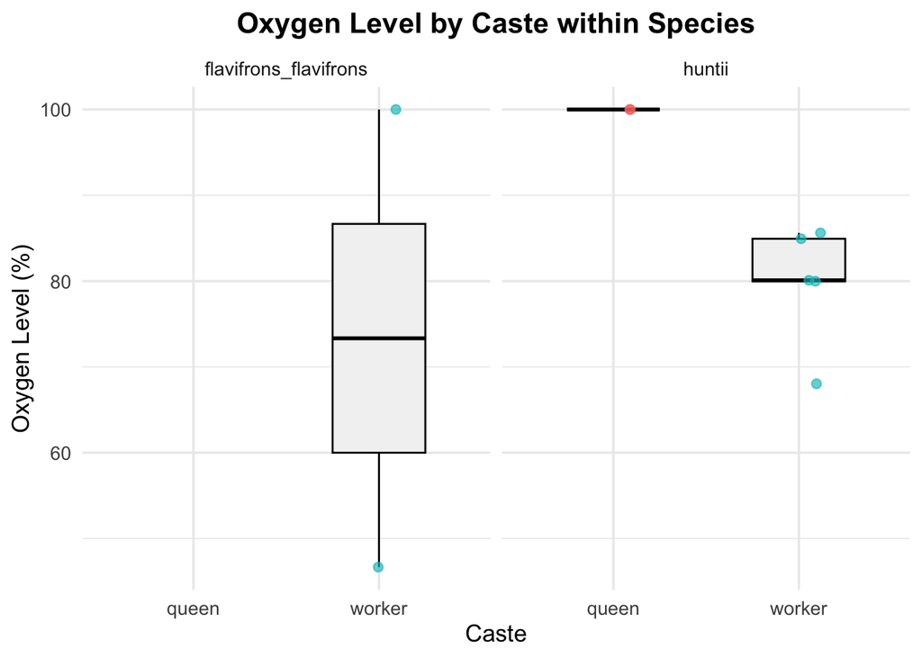

```r
metadata %>%
  filter(caste %in% c("queen", "worker"),
         species_id %in% c("flavifrons_flavifrons", "huntii")) %>%
  ggplot(aes(x = caste, y = Oxygen_level, color = caste)) +
  sm_boxplot() +
  facet_wrap(~species_id) +
  labs(
    title = "Oxygen Level by Caste within Species",
    x = "Caste",
    y = "Oxygen Level (%)"
  ) +
  theme_minimal(base_size = 13) +
  theme(
    legend.position = "none",
    plot.title = element_text(face = "bold", hjust = 0.5)
  )
```

### Observation: Flavifron queens have oxygen levels labeled as NAs. Only huntii produced visualizable results. Sample size is small, but queens have higher oxygen levels compared to workers.

T-test for differences:

```r
t.test(Oxygen_level ~ caste, data = metadata %>%
  filter(species_id == "huntii", caste %in% c("queen", "worker")))
```

```
##
##  Welch Two Sample t-test
##
## data:  Oxygen_level by caste
## t = 6.429, df = 4, p-value = 0.00301
## alternative hypothesis: true difference in means between group queen and group worker is not equal to 0
## 95 percent confidence interval:
##  11.51504 29.02112
## sample estimates:
##  mean in group queen mean in group worker
##            100.00000             79.73192
```

### Conculsion: Queen bumblebees have more aerobic gut microbiomes than workers for the species Huntii (p=0.003)!